# Introduction to Cyclical Ecological Trajectory Analysis

Nicolas Djeghri, Miquel De Cáceres, Anthony Sturbois

LEMAR, EMF-CREAF, VivArmor Nature

# Outline

1. Aims and rationale of CETA
2. CETA-specific conceptual and geometric elements
3. Characterizing and comparing CETA trajectories
4. Cyclical shifts

[figure not shown]

M.C. Escher - Dragon, 1952

# 1. Introduction

## About Cyclical Ecological Trajectory Analysis

**Aims and domain of application**

Cyclical Ecological Trajectory Analysis (CETA) is an extension of the ETA framework to analyze cyclical ecological dynamics (seasons, day/night cycles…).

**Rationale and general approach**

- CETA proceeds by sub-setting trajectories presenting cyclical dynamics into sub-trajectories of interest (Cycles, and fixed date trajectories).
- CETA trajectories can then be described and compared as is done for other, non-CETA, trajectories.
- Cycles specific geometries sometimes necessitate using dedicated metrics.
- CETA also allows computing **Cyclical Shifts**, a multidimensional equivalent of the notion of phenological advances and delays.

**Software**

CETA is readily implemented within the **ecotraj** package (from version 1.0.0)

[figure not shown]

**Package call**

```r
library(ecotraj)
```

1. Aims and rationale of CETA

# 2. CETA-specific conceptual and geometric elements

## Conceptual and geometric elements

The most important elements of CETA are:

[output not shown]

Together these elements allow defining CETA-specific trajectories:

| Trajectory | Notation | Description |
| --- | --- | --- |
| *Cycles* | $C$ | A Cycle is a special-case of trajectory section obtained from $T$ of duration $DUR_C$. |
| *Fixed date trajectories* | $fdT$ | Fixed date trajectories are the trajectories joining the ecological state of the same date $đ$ in a given cyclical trajectory. |

2. CETA-specific conceptual and geometric elements

## Defining some toy CETA trajectories

Start by defining one cyclical trajectory with three cycles:

```r
times <- 0:30 #The sampling times of the time series
DurC <- 10 #The duration of the cycles (i.e. the periodicity of the time series)
dates <- times%%DurC #The dates associated to each times
site <- rep(c("A"),length(times)) #The sites associated to each times (only one)
trend <- 0.05 #A trend that will be applied to the cycles to make it more interesting
noise <- 0.05 #A noise term to make things less perfect

#Make cyclical data
x <- sin((times*2*pi)/DurC)+trend*times+rnorm(length(times),mean=0,sd=noise)
y <- cos((times*2*pi)/DurC)+rnorm(length(times),mean=0,sd=noise)
mat <- cbind(x,y)

#Express it as a distance matrix
dmat <- dist(mat)

#Finally make it a trajectory object:
x <- defineTrajectories(dmat, sites = site, times = times)
```

2. CETA-specific conceptual and geometric elements

## Visualization of the cylical trajectory

```r
trajectoryPCoA(x,lwd = 2,length = 0.2)
```

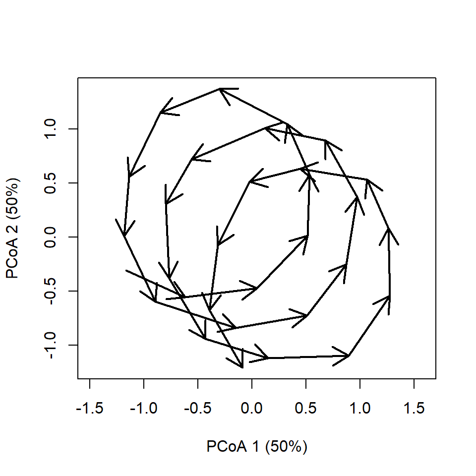

2. CETA-specific conceptual and geometric elements

## Extracting and visualizing the cycles…

Extraction of cycles…

```r
cycle <- extractCycles(x,cycleDuration = DurC)
```

…and visualization

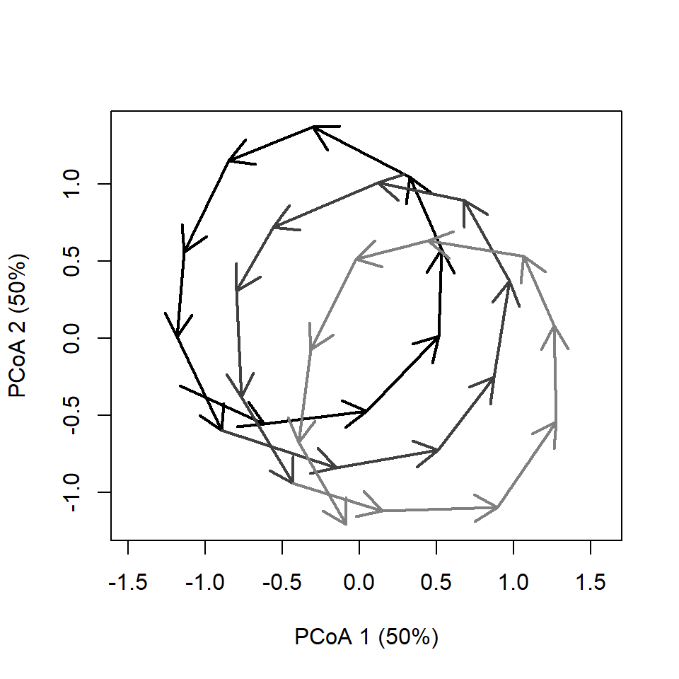

```r
cyclePCoA(cycle,lwd = 2,length = 0.2)
```

2. CETA-specific conceptual and geometric elements

## …and the fixed date trajectories

Extraction of fixed date trajectories…

```r
fdtraj <- extractFixedDateTrajectories(x,
                                       cycleDuration = DurC,
                                       namesFixedDate = paste0("Date_",1:10))
```

…and visualization

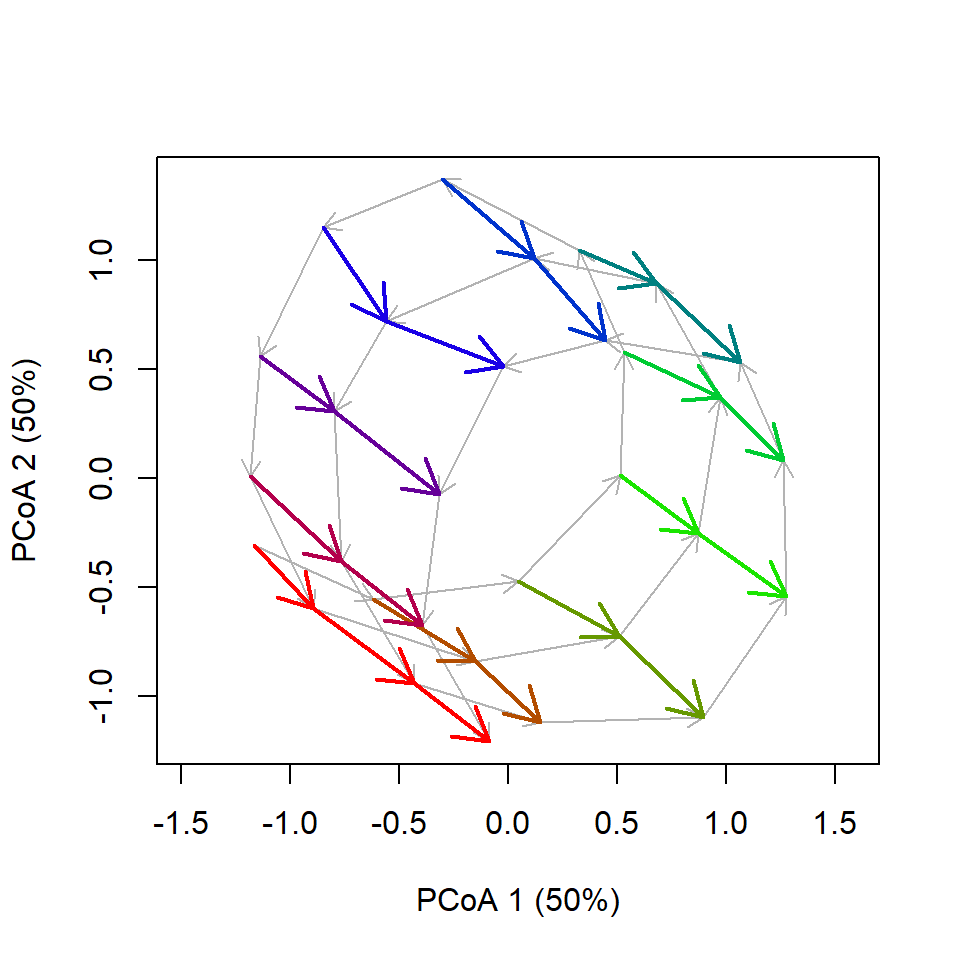

```r
fixedDateTrajectoryPCoA(fdtraj,lwd = 2,length = 0.2)
```

2. CETA-specific conceptual and geometric elements

## Object structure

Note that the structure of the **ecotraj/CETA** objects is very similar to what you already know.

```r
names(cycle)
```

```
[1] "d"        "metadata"
```

```r
names(fdtraj)
```

```
[1] "d"        "metadata"
```

But cycles have some specificities

```r
head(cycle$metadata)
```

```
  sites cycles surveys times dates internal
1     A   A_C1       1     0     0     TRUE
2     A   A_C1       2     1     1     TRUE
3     A   A_C1       3     2     2     TRUE
4     A   A_C1       4     3     3     TRUE
5     A   A_C1       5     4     4     TRUE
6     A   A_C1       6     5     5     TRUE
```

```r
head(fdtraj$metadata)
```

```
  sites          fdT surveys times dates
1     A A_fdT_Date_1       1     0     0
2     A A_fdT_Date_2       1     1     1
3     A A_fdT_Date_3       1     2     2
4     A A_fdT_Date_4       1     3     3
5     A A_fdT_Date_5       1     4     4
6     A A_fdT_Date_6       1     5     5
```

We won’t get into the detail now but you can check the [CETA vignette](https://emf-creaf.github.io/ecotraj/articles/IntroductionCETA.html) for more details.

2. CETA-specific conceptual and geometric elements

# 3. Characterizing and comparing CETA trajectories

## Metrics for cycles

Cycle have particular geometries (they loop back on themselves) implying that some classical ETA metrics are not adapted and must be changed.

Note that $\theta$ can be defined by ecological states outside the cycle of interest. This is why the **ecotraj** implementation uses the cyclical trajectory instead of the cycles:

```r
cycleConvexity(x,DurC)#Note: the function takes x instead of cycle as input
```

```
     A_C1      A_C2      A_C3
       NA 0.9853347 1.0026356
```

**Note**

The function for the first cycle returns $NA$, this is expected but can you find why?.

**ecotraj** has a function dedicated to obtain multiple summary metrics for cycles:

```r
cycleMetrics(x,DurC)#Again, the function takes x instead of cycle as input
```

```
  cycle site  n t_start t_end   length mean_speed mean_angle convexity
1  A_C1    A 10       0    10 6.199856  0.6199856         NA        NA
2  A_C2    A 10      10    20 6.407492  0.6407492   35.47205 0.9853347
3  A_C3    A 10      20    30 6.126817  0.6126817   36.09488 1.0026356
  internal_ss internal_variance
1    8.844807         0.9827563
2    9.142359         1.0158177
3    8.594349         0.9549277
```

3. Characterizing and comparing CETA trajectories

## Metrics for fixed date trajectories

Fixed trajectories are regular trajectories and can be studied with classical **ecotraj** functions:

```r
trajectoryMetrics(fdtraj)
```

```
      trajectory site n t_start t_end duration    length mean_speed mean_angle
1   A_fdT_Date_1    A 4       0    30       30 1.4097970 0.04699323  5.7380567
2   A_fdT_Date_2    A 3       1    21       20 0.9547601 0.04773801 11.3062186
3   A_fdT_Date_3    A 3       2    22       20 1.0612207 0.05306103 15.4829783
4   A_fdT_Date_4    A 3       3    23       20 0.9403754 0.04701877  0.7247428
5   A_fdT_Date_5    A 3       4    24       20 0.8976467 0.04488234 20.1369645
6   A_fdT_Date_6    A 3       5    25       20 0.9143858 0.04571929 20.5093248
7   A_fdT_Date_7    A 3       6    26       20 1.0541666 0.05270833  9.1886874
8   A_fdT_Date_8    A 3       7    27       20 1.0915882 0.05457941 35.0130502
9   A_fdT_Date_9    A 3       8    28       20 1.0405884 0.05202942  2.0222800
10 A_fdT_Date_10    A 3       9    29       20 1.0439426 0.05219713  4.9323857
   directionality internal_ss internal_variance
1       0.9652271   1.1556151         0.3852050
2       0.9371877   0.4562093         0.2281046
3       0.9139835   0.5563282         0.2781641
4       0.9959737   0.4426065         0.2213033
5       0.8881280   0.3956648         0.1978324
6       0.8860593   0.4126802         0.2063401
7       0.9489517   0.5537656         0.2768828
8       0.8054831   0.5605347         0.2802674
9       0.9887651   0.5471373         0.2735686
10      0.9725979   0.5458818         0.2729409
```

3. Characterizing and comparing CETA trajectories

[figure not shown]